# HarvardX PH125.3x – Data Science: Probability

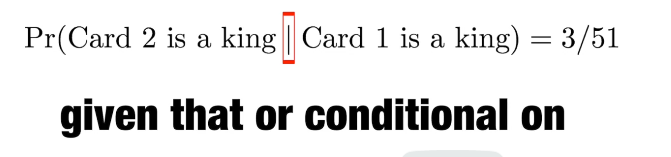

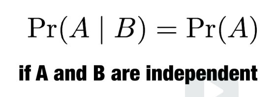

[figure not shown]

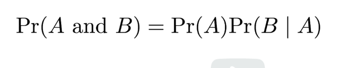

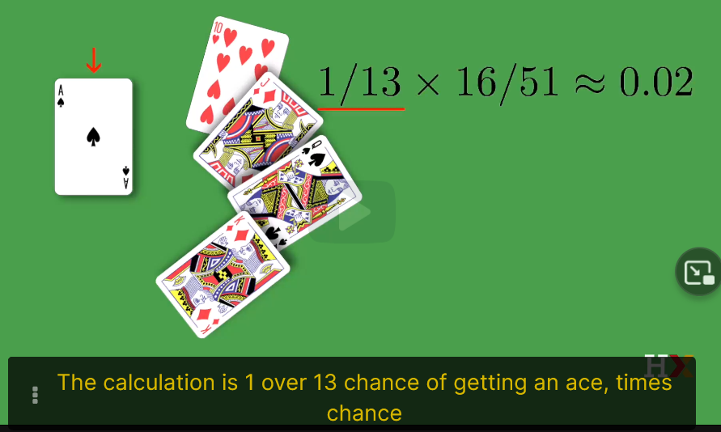

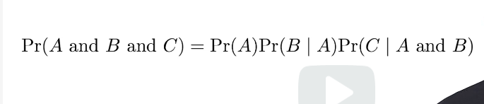

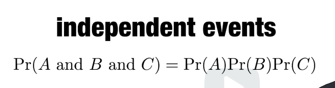

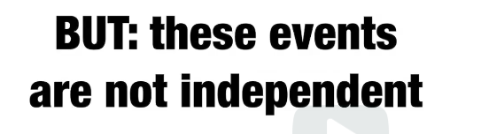

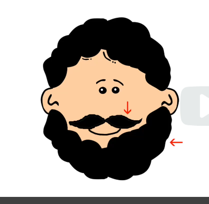

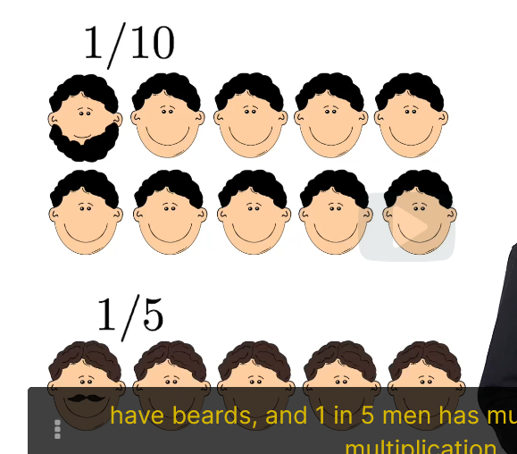

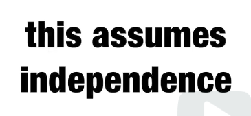

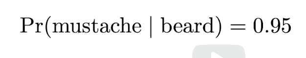

# Assessment: Introduction to Discrete Probability

Assessment due Jun 15, 2022 10:43 AWST

## Probability of cyan

1/1 point (graded)

One ball will be drawn at random from a box containing: 3 cyan balls, 5 magenta balls, and 7 yellow balls. What is the probability that the ball will be cyan? correct

## Probability of not cyan

1/1 point (graded)

One ball will be drawn at random from a box containing: 3 cyan balls, 5 magenta balls, and 7 yellow balls. What is the probability that the ball will not be cyan? correct

## Sampling without replacement

1/1 point (graded)

Instead of taking just one draw, consider taking two draws. You take the second draw without returning the first draw to the box. We call this sampling without replacement. What is the probability that the first draw is cyan and that the second draw is not cyan?

Provide at least 3 significant digits. correct

## Sampling with replacement

1/1 point (graded)

Now repeat the experiment, but this time, after taking the first draw and recording the color, return it back to the box and shake the box. We call this sampling with replacement. What is the probability that the first draw is cyan and that the second draw is not cyan? correct

Have a question about these assessments? Search the discussion forum BEFORE posting below.

Some reminders:

[output not shown]

Discussion: Assessment: Introduction to discrete probability’ Topic: Section 1 / Assessment: Introduction to discrete probability

a box containing: 3 cyan balls, 5 magenta balls, and 7 yellow balls.

# What is the probability that the first draw is cyan and that the second draw is not cyan?

Pr(A) Cyan

Pr(B) not Cyan

Pr(A and B) = Pr(A) x Pr(B|A) = 3/15 x 12/14 = 1/5 x 6/7 = 6/35

3/15 x 12/15 1/5 x 4/5 4/25

# Introduction to DataCamp

DataCamp

You are about the take the first DataCamp assessment. In this course we will be using the DataCamp platform for some assessments. DataCamp provides an R console and and a script editor right here on your browser. Here we give a brief DataCamp tutorial. If you are already familiar with DataCamp you can skip this section and proceed to the next section

The DataCamp interface has four panels. They are:

```
The Information Panel: General information about the assessment.
The Instructions Panel: Exercise instructions. The multiple choice questions appear here when applicable.
The Editor: Here is where you type and edit your answers in the form of an R script. Example code also appears here. The editor also includes reminders of the instructions.  Note that # denotes comments. These are not run as code, instead, they tell others what your code is about!
R console: This is where R commands get executed. You can send commands from the editor to the console but you can also type in commands directly to test out code.
```

Here is a screenshot of what DataCamp looks like:

Image of DataCamp Platform

[figure not shown]

There are two ways to send commands from the editor to the console:

1. If you hit the Submit Answer button, the entire code in the editor gets executed and your answer is evaluated. Remember, after you click Submit Answer in an assessment, your code will be evaluated. If you do not take the hint, you get unlimited tries.
2. If your cursor is on the editor and you hit command-return on a Mac or control-return on Windows, that line gets executed in the console. You do not submit an answer when you do this. This is a good way to test your script before you submit.

Tip: DataCamp suggests useful keyboard shortcuts after most exercises.

[figure not shown]

After submit answer on the platform

# DataCamp Assessment: Introduction to Discrete Probability

Assessment due Jun 15, 2022 10:43 AWST

This assessment covers the basics of discrete probability. There are two parts to this assessment: the first part is a set of questions on the edX platform, and the second part is a set of coding questions on the DataCamp platform.

In this assessment, you will learn about the fundamentals of discrete probability through looking at examples of sampling from an urn with and without replacement.

By clicking OK, you agree to DataCamp’s privacy policy: https://www.datacamp.com/privacy-policy. Note that you might need to disable your pop-up blocker, or allow “www.datacamp.com” in your pop-up blocker allowed list. When you have completed the exercises, return to edX to continue your learning.

Have a question about this assessment? Search the discussion forum to see if someone else has asked or answered your question BEFORE posting below.

Some reminders:

[output not shown]

Discussion: DataCamp Assessment: Introduction to discrete probability Topic: Section 1 / DataCamp Assessment: Introduction to discrete probability

## Exercise 1. Probability of cyan - generalized

In the edX exercises for this section, we calculated some probabilities by hand. Now we’ll calculate those probabilities using R.

One ball will be drawn at random from a box containing: 3 cyan balls, 5 magenta balls, and 7 yellow balls.

What is the probability that the ball will be cyan? Instructions 70 XP

```
Define a variable p as the probability of choosing a cyan ball from the box.
Print the value of p.
```

Hint

```
Calculate the proportion of balls in the box that are cyan and assign that value to the variable p.
To print the contents of a variable, write the variable name in a new line of code.
```

```r
cyan <- 3
magenta <- 5
yellow <- 7

# Assign a variable `p` as the probability of choosing a cyan ball from the box
#p <- rep(c("cyan", "magenta", "yellow"), times=c(3, 5, 7))
p <- cyan/(cyan + magenta + yellow)

# Print the variable `p` to the console
p
```

```
## [1] 0.2
```

## Exercise 2. Probability of not cyan - generalized

We defined the variable p as the probability of choosing a cyan ball from a box containing: 3 cyan balls, 5 magenta balls, and 7 yellow balls.

What is the probability that the ball you draw from the box will NOT be cyan? Instructions 100 XP

```
Using the probability of choosing a cyan ball, p, calculate the probability of choosing any other ball.
```

```r
# `p` is defined as the probability of choosing a cyan ball from a box containing: 3 cyan balls, 5 magenta balls, and 7 yellow balls.
# Using variable `p`, calculate the probability of choosing any ball that is not cyan from the box

1-p
```

```
## [1] 0.8
```

## Exercise 3. Sampling without replacement - generalized

Instead of taking just one draw, consider taking two draws. You take the second draw without returning the first draw to the box. We call this sampling without replacement.

What is the probability that the first draw is cyan and that the second draw is not cyan? Instructions 100 XP

```
Calculate the conditional probability p_2 of choosing a ball that is not cyan after one cyan ball has been removed from the box.
Calculate the joint probability of both choosing a cyan ball on the first draw and a ball that is not cyan on the second draw using p_1 and p_2.
```

```r
cyan <- 3
magenta <- 5
yellow <- 7

# The variable `p_1` is the probability of choosing a cyan ball from the box on the first draw.
p_1 <- cyan / (cyan + magenta + yellow)

# Assign a variable `p_2` as the probability of not choosing a cyan ball on the second draw without replacement.

# Calculate the probability that the first draw is cyan and the second draw is not cyan using `p_1` and `p_2`.



# The variable `p_1` is the probability of choosing a cyan ball from the box on the first draw.
p_1 <- cyan / (cyan + magenta + yellow)
p_1
```

```
## [1] 0.2
```

```r
# Assign a variable `p_2` as the probability of not choosing a cyan ball on the second draw without replacement.
p_2 <- (magenta + yellow)/(cyan + magenta + yellow - 1)
p_2
```

```
## [1] 0.8571429
```

```r
# Calculate the probability that the first draw is cyan and the second draw is not cyan using `p_1` and `p_2`.
p_1 * p_2
```

```
## [1] 0.1714286
```

## Exercise 4. Sampling with replacement - generalized

Now repeat the experiment, but this time, after taking the first draw and recording the color, return it back to the box and shake the box. We call this sampling with replacement.

What is the probability that the first draw is cyan and that the second draw is not cyan? Instructions 100 XP

```
Calculate the probability p_2 of choosing a ball that is not cyan on the second draw, with replacement.
Next, use p_1 and p_2 to calculate the probability of choosing a cyan ball on the first draw and a ball that is not cyan on the second draw (after replacing the first ball).
```

```r
cyan <- 3
magenta <- 5
yellow <- 7

# The variable 'p_1' is the probability of choosing a cyan ball from the box on the first draw.
p_1 <- cyan / (cyan + magenta + yellow)

# Assign a variable 'p_2' as the probability of not choosing a cyan ball on the second draw with replacement.
p_2 <- 1- p_1

# Calculate the probability that the first draw is cyan and the second draw is not cyan using `p_1` and `p_2`.
p_1 * p_2
```

```
## [1] 0.16
```

```r
# Solution =====================================================================================================================
cyan <- 3
magenta <- 5
yellow <- 7

# The variable 'p_1' is the probability of choosing a cyan ball from the box on the first draw.
p_1 <- cyan / (cyan + magenta + yellow)

# Assign a variable 'p_2' as the probability of not choosing a cyan ball on the second draw with replacement.
p_2 <- 1 - (cyan) / (cyan + magenta + yellow)

# Calculate the probability that the first draw is cyan and the second draw is not cyan using `p_1` and `p_2`.
p_1 * p_2
```

```
## [1] 0.16
```

## End of Assessment: Introduction to Discrete Probability

This is the end of the programming assignment for this section. Please DO NOT click through to additional assessments from this page. Please DO answer the question on this page. If you do click through, your scores may NOT be recorded.

Click on “Awesome” to get the “points” for this question and then return to the course on edX.

You can close this window and return to Data Science: Probability. Answer the question 50XP Possible Answers

[output not shown]

## Course / Section 1: Discrete Probability / 1.2 Combinations and Permutations

# Combinations and Permutations